# Growth Opportunities for Budweiser

Alex Gilbert and Yves Hughes

10/23/2020

This file contains the code and partial analysis of the “Brewery” and “Beer” data sets as provided by the executive suite of Budweiser. The purpose of this analysis is to make recommendations to the CEO and CFO on potential growth strategy including brewery acquisitions. The analysis also includes an explanation of assumptions, drawbacks of the methodology, and opportunities for future analysis.

Important note about the data:

Data about IBU and ABV was incomplete so generalizations had to be made about the data. There is a description below about the various methodologies conceived and attempted, but in the end it was determined to omit rows with missing values. We found this to give the truest account of the most important factors.

## Load Library Dependencies

```r
library(readr)
library(dplyr)
```

```r
library(magrittr)
library(ggplot2)
library(class)
library(caret)
library(cowplot)
library(forcats)
```

## Load initial data

```r
breweries <- read_csv("D:/School/Courses/Doing Data Science/Repos/MSDS_6306_Doing-Data-Science/Unit 8 and 9 Case Study 1/Breweries.csv")
beers <- read_csv("D:/School/Courses/Doing Data Science/Repos/MSDS_6306_Doing-Data-Science/Unit 8 and 9 Case Study 1/Beers.csv")
###  Viewed as table, visualization may not be required for this, just the count.

b = table(breweries$State)
t = as.data.frame(b)
names(t)[1] = 'State'
t
```

```
##    State Freq
## 1     AK    7
## 2     AL    3
## 3     AR    2
## 4     AZ   11
## 5     CA   39
## 6     CO   47
## 7     CT    8
## 8     DC    1
## 9     DE    2
## 10    FL   15
## 11    GA    7
## 12    HI    4
## 13    IA    5
## 14    ID    5
```

[output cut: 37 more lines]

#### Analysis Question # 2 – Merge beer data with the breweries data. Print first 6 and last 6

```r
colnames(breweries)[1] = "Brewery_id"

brewbeers = merge(breweries, beers, by ="Brewery_id")

head(brewbeers, n=6)
```

```
##   Brewery_id            Name.x        City State        Name.y Beer_ID   ABV
## 1          1 NorthGate Brewing Minneapolis    MN       Pumpion    2689 0.060
## 2          1 NorthGate Brewing Minneapolis    MN    Stronghold    2688 0.060
## 3          1 NorthGate Brewing Minneapolis    MN   Parapet ESB    2687 0.056
## 4          1 NorthGate Brewing Minneapolis    MN  Get Together    2692 0.045
## 5          1 NorthGate Brewing Minneapolis    MN Maggie's Leap    2691 0.049
## 6          1 NorthGate Brewing Minneapolis    MN    Wall's End    2690 0.048
##   IBU                               Style Ounces
## 1  38                         Pumpkin Ale     16
## 2  25                     American Porter     16
## 3  47 Extra Special / Strong Bitter (ESB)     16
## 4  50                        American IPA     16
## 5  26                  Milk / Sweet Stout     16
## 6  19                   English Brown Ale     16
```

```r
tail(brewbeers, n=6)
```

```
##      Brewery_id                        Name.x          City State
## 2405        556         Ukiah Brewing Company         Ukiah    CA
## 2406        557       Butternuts Beer and Ale Garrattsville    NY
## 2407        557       Butternuts Beer and Ale Garrattsville    NY
## 2408        557       Butternuts Beer and Ale Garrattsville    NY
## 2409        557       Butternuts Beer and Ale Garrattsville    NY
## 2410        558 Sleeping Lady Brewing Company     Anchorage    AK
##                         Name.y Beer_ID   ABV IBU                   Style Ounces
## 2405             Pilsner Ukiah      98 0.055  NA         German Pilsener     12
## 2406         Porkslap Pale Ale      49 0.043  NA American Pale Ale (APA)     12
## 2407           Snapperhead IPA      51 0.068  NA            American IPA     12
## 2408         Moo Thunder Stout      50 0.049  NA      Milk / Sweet Stout     12
## 2409  Heinnieweisse Weissebier      52 0.049  NA              Hefeweizen     12
## 2410 Urban Wilderness Pale Ale      30 0.049  NA        English Pale Ale     12
```

#### Analysis Question # 3 – Address the missing values in each column

Our initial thoughts were that dropping missing values would leave out too much important information. We immediately attempted to use the KNN method to predict missing values. We found it impossible as we did not have enough explanatory, numeric values to utilize.

We then moved on methodologies that used 1) a median value or 2) a random value. In each of these cases we found the results to skew the date too much towards the chosen number due to the fact that there was such a high number of missing values.

In the end, we found that dropping the beers with missing data altogether was the best decision. Although it reduced the number of data points, we felt that the ABV and IBU were the data points on which we most relied on accuracy for our questions of interest, and imputing those values would do our study an injustice.

The other potential methodology we considered was calculating the median value of IBU and ABV for each style of beer and replacing missing values with the relevant median. Unfortunately, due to time constraints, we did not employ this method.

```r
# create new dataset without missing data

bbcomplete <- na.omit(brewbeers)
```

### Analysis Question # 1 – How many breweries are in each state?

```r
table(bbcomplete$State)
```

```
##
##  AK  AL  AR  AZ  CA  CO  CT  DC  DE  FL  GA  HI  IA  ID  IL  IN  KS  KY  LA  MA
##  17   9   1  23 135 146   6   4   1  37   7  18  25  17  39  91  19  14  10  51
##  MD  ME  MI  MN  MO  MS  MT  NC  ND  NE  NH  NJ  NM  NV  NY  OH  OK  OR  PA  RI
##  10   7  38  46  29  11  23  30   3   9   2   8   6   8  46  32  11  87  47  20
##  SC  TN  TX  UT  VA  VT  WA  WI  WV  WY
##   5   5  88  11  35  17  43  42   2  12
```

```r
as.data.frame(table(bbcomplete$State))
```

```
##    Var1 Freq
## 1    AK   17
## 2    AL    9
## 3    AR    1
## 4    AZ   23
## 5    CA  135
## 6    CO  146
## 7    CT    6
## 8    DC    4
## 9    DE    1
## 10   FL   37
## 11   GA    7
## 12   HI   18
## 13   IA   25
## 14   ID   17
```

[output cut: 36 more lines]

```r
arrange(t,Freq)
```

```
##    State Freq
## 1     DC    1
## 2     ND    1
## 3     SD    1
## 4     WV    1
## 5     AR    2
## 6     DE    2
## 7     MS    2
## 8     NV    2
## 9     AL    3
## 10    KS    3
## 11    NH    3
## 12    NJ    3
## 13    TN    3
## 14    HI    4
```

[output cut: 37 more lines]

#### Analysis Question # 4 – Not complete – barplot(bbcomplete$IBU, State = bbcomplete$State) ## !!Need to barplot this

```r
bbcomplete %>% group_by(State) %>% summarize(medianABV=median(ABV), medianIBU=median(IBU))
```

```
## # A tibble: 50 x 3
##    State medianABV medianIBU
##    <chr>     <dbl>     <dbl>
##  1 AK        0.057      46
##  2 AL        0.06       43
##  3 AR        0.04       39
##  4 AZ        0.055      20
##  5 CA        0.058      42
##  6 CO        0.065      40
##  7 CT        0.061      29
##  8 DC        0.059      47.5
##  9 DE        0.055      52
## 10 FL        0.062      55
## # ... with 40 more rows
```

```r
bbmedians <- bbcomplete %>% group_by(State) %>% summarize(medianABV=median(ABV), medianIBU=median(IBU))
```

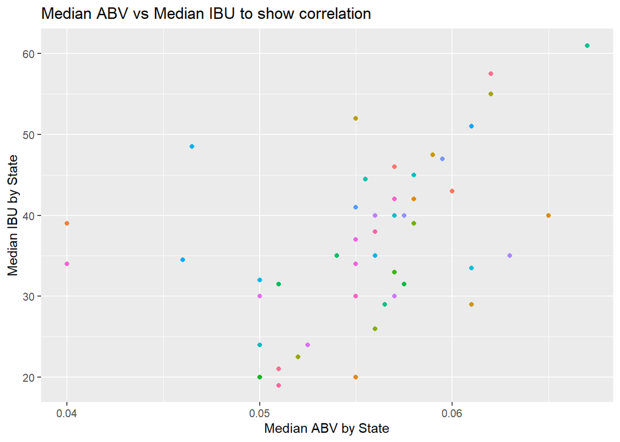

```r
# Dot plot of medians

bbmedians %>% ggplot(aes(x=medianABV,y = medianIBU, color = State)) +
  geom_point() +
  guides(color=FALSE) +
  ggtitle("Median ABV vs Median IBU to show correlation") +
  labs(x = "Median ABV by State", y = "Median IBU by State")
```

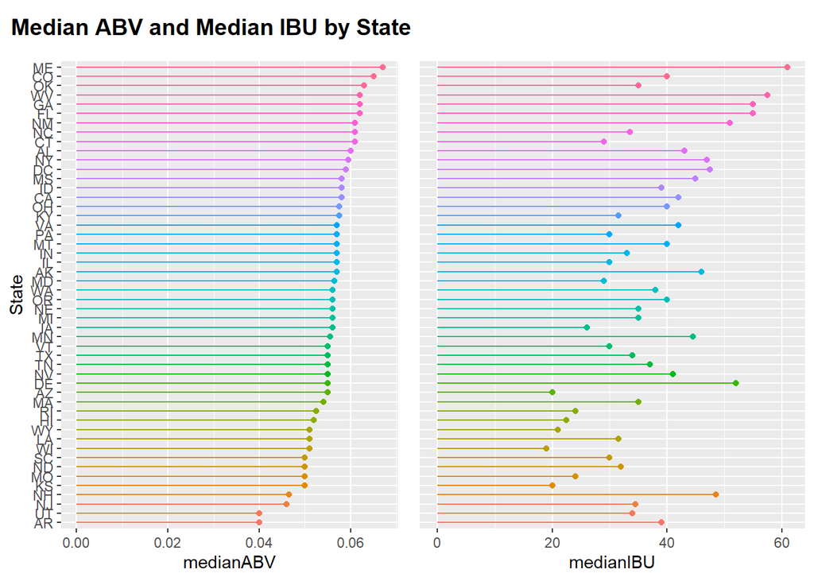

```r
# Lollipop plot of ABV by State

lolliABV <- bbmedians %>% mutate(State = fct_reorder(State, medianABV)) %>% ggplot(aes(x = State, y = medianABV, color = State, sort = "ascending", add = "segments")) +
  geom_point(stat='identity') +
  coord_flip() +
  geom_segment(aes(x=State, xend=State, y = 0, yend=medianABV)) +
  guides(color=FALSE)


# Lollipop plot of IBU by State

lolliIBU <- bbmedians %>% mutate(State = fct_reorder(State, medianABV)) %>% ggplot(aes(x = State, y = medianIBU, color = State, sort = "ascending", add = "segments")) +
  geom_point(stat='identity') +
  coord_flip() +
  geom_segment(aes(x=State, xend=State, y = 0, yend=medianIBU)) +
  guides(color=FALSE) +
  theme(axis.title.y=element_blank(),
        axis.text.y=element_blank(),
        axis.ticks.y=element_blank())

plot_row <- plot_grid(lolliABV,lolliIBU)


title <- ggdraw() +
  draw_label(
    "Median ABV and Median IBU by State",
    fontface = 'bold',
    x = 0,
    hjust = 0
  ) +
  theme(
    # add margin on the left of the drawing canvas,
    # so title is aligned with left edge of first plot
    plot.margin = margin(0, 0, 0, 7)
  )
plot_grid(
  title, plot_row,
  ncol = 1,
  # rel_heights values control vertical title margins
  rel_heights = c(0.1, 1)
)
```

### Analysis Question # 5 – Which state has the maximum alcoholic (ABV) beer? Which state has the most bitter (IBU) beer?

```r
bbcomplete[which.max(bbcomplete$ABV),]  #strange-- I am getting ID2 KY but in another example I am getting CO
```

```
##   Brewery_id                    Name.x       City State         Name.y Beer_ID
## 9          2 Against the Grain Brewery Louisville    KY London Balling    2685
##     ABV IBU              Style Ounces
## 9 0.125  80 English Barleywine     16
```

```r
bbcomplete[which.max(bbcomplete$IBU),]
```

```
##      Brewery_id                  Name.x    City State                    Name.y
## 1857        375 Astoria Brewing Company Astoria    OR Bitter Bitch Imperial IPA
##      Beer_ID   ABV IBU                          Style Ounces
## 1857     980 0.082 138 American Double / Imperial IPA     12
```

### Analysis Question # 6 – Comment on summary stats and distribution of ABV

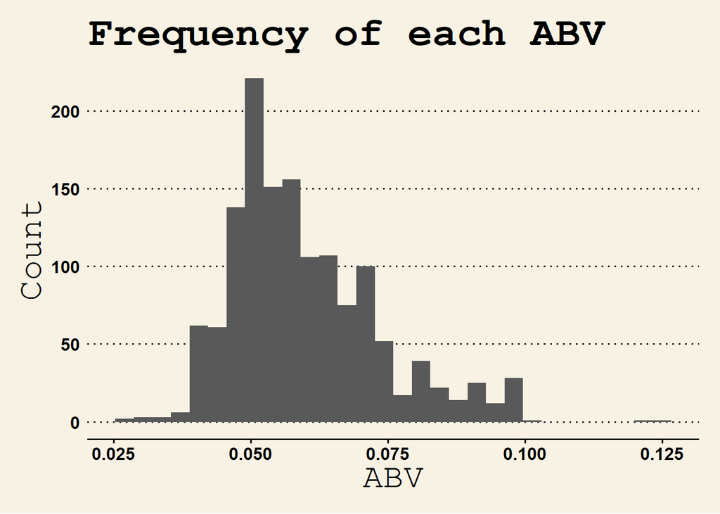

```r
bbcomplete %>% ggplot(aes(x = ABV)) +
  geom_histogram() +
  ggthemes::theme_wsj() +
  ggtitle("Frequency of each ABV") +
  theme(axis.title = element_text()) + ylab('Count')
```

```r
# There is a slight right-skewed distribution of ABV in beers. The large majority of beers have an ABV within .04 and .07.
# There are very few beers that have below .04 ABV, but there seems to be limited popularity of beers as high as .1, with
# several specialty beers around .12 ABV.
```

### Analysis Question # 7 – Relationship between IBU and ABV scatter plot.

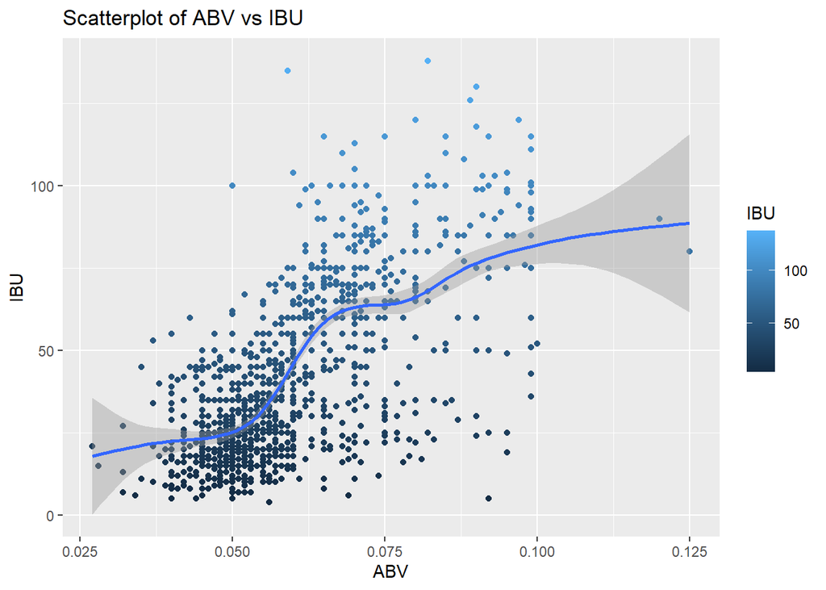

```r
bbcomplete %>% ggplot(aes(x=ABV, y=IBU, color=IBU)) +
  geom_point() +
  geom_smooth() +
  ggtitle("Scatterplot of ABV vs IBU")
```